# Probabilidad Computacional y Estadística

Ingeniería de software y computación

Ph.D. Pablo Eduardo Caicedo Rodríguez

2023-08-01

# Probabilidad Computacional y Estadística

## El Profesor

### Educación

Doctor en Ciencias de la Electrónica. Magister en Ingeniería Electrónica y Telecomunicaciones Ingeniero en Electrónica y Telecomunicaciones

### Intereses

Biomecánica, Dispositivos para el análisis de movimiento humano, ciencia de los datos.

### Desempeño

Profesor de la Facultad de Ingeniería

Invest. Línea de Percep. Avanz. y Robótica – GITA

Director Grupo de Investigación MEDES.

### Contacto:

pablo.caicedo.r@uniautonoma.edu.co

## Contenido del curso

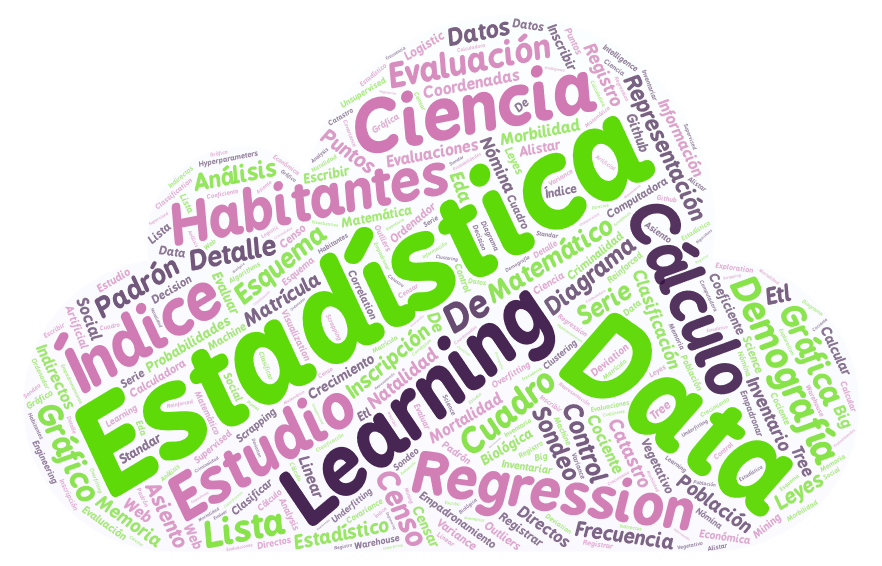

1. Introducción a la probabilidad y la estadística.
2. Análisis exploratorio de datos.
3. Modelos básicos de representación estadística.

## Evaluación

1. Varios 001. Quices y talleres (15%) (Lo puedo cambiar!!!)
2. Parcial 002. Probabilidad, conteo y funciones de densidad de probabilidad (20%)
3. Parcial 003. Análisis de datos a partir de estadística descriptiva (20%)
4. Consigna 004. Proyecto Final (45%)

[figure not shown]

## Recursos

### Clases

Lunes, Miércoles y Viernes 9:00 – 11:00 Sala 502

### Grupo Teams

### Software

**Interpretes:** R.

**IDE:** Visual Studio Code, Google Colaboratory [R](https://colab.to/r), RStudio, PyCharm, Dataspell

**Seguimiento de Aprendizaje:** Moodle

## Bibliografía

1. P. Dangeti, Statistics for Machine Learning. 2017.
2. A. P. Field, J. Miles, and Z. Field, Discovering statistics using R. London; Thousand Oaks, Calif.: Sage, 2012.
3. D. Forsyth, Probability and Statistics for Computer Science. Cham: Springer International Publishing, 2018.
4. C. Guisande González, A. Vaamonde Liste, and A. Barreiro Felpeto, Tratamiento de datos con R, Statistica y SPSS. 2013.
5. C. Heumann, M. Schomaker, and Shalabh, Introduction to Statistics and Data Analysis. Cham: Springer International Publishing, 2016.
6. N. S. Matloff, Probability and statistics for data science: math + R + data. Boca Raton: CRC Press, Taylor & Francis Group, 2019.
7. W. Menhenhall, R. Beaver, and B. Beaver, Introducción a la probabilidad y estadística. 2016.
8. M. R. C. Rubio, Estadística con aplicaciones en R. Bogotá: Fundacion Universidad de Bogota Jorge Tadeo Lozano, 2019.
9. P. Bruce, A. Bruce, y P. Gedeck, Practical Statistics for Data Scientists, Segunda Edición. Sebastopol, CA: O’Reilly, 2020.

# Introducción a R

## Que es R?

```
    graph LR
    A[Que es R]
    A-->B[Herramienta de gran versatilidad]
    A-->C[Gran Popularidad entre la comunidad<br/>académica y científica]
    B--Que hace?-->D1>Cálculos numéricos]
    B--Que hace?-->D2>Gráficas y figuras de alta calidad]
    B--Que es?-->D3>Lenguaje de Programación]
    B--En que campos?-->D4>Ciencia, economía, ingeniería, etc]
    C--Licenciamiento?-->E1>GNU GLP: Código Abierto]
    C--Ampliaciones?-->E2>Numerosas librerías]
    C--Ayuda?-->E3>Comunidades, foros, tutoriales, etc]
```

## Un poquito de historia y herramientas

**Consejo**

- Creado en 1993 por Robert Gentleman y Ross Ihaka en la universidad de Auckland (Nueva Zelanda)
- En la actualidad: miles de personas en todo el mundo que colaboran en su desarrollo
- **Propósito:** contar con una plataforma libre y gratuita para desarrollar algoritmos numéricos y estadísticos

**Consejo**

[RStudio](https://posit.co/download/rstudio-desktop/)

Es un IDE (Entorno de Desarrollo Integrado): permite utilizar R de manera más cómoda en algunos aspectos

[figure not shown]

## Otro poquito de herramientas

### [Google Colaboratory R](https://colab.to/r)

Permite escribir y ejecutar código de R en tu navegador, con

- Sin configuración requerida
- Acceso sin costo a GPU
- Facilidad para compartir

### [Deepnote](https://deepnote.com/)

Similar a [Google Colaboratory R](https://colab.to/r), sin embargo permite el trabajo colaborativo más fácilmente. Acceso a licencia educativa con su correo electrónico de la Universidad

### [Instalación de R](https://cran.r-project.org/)…. solo windows

- [R](https://cran.r-project.org/bin/windows/base/R-4.2.3-win.exe)
- [RTools](https://cran.r-project.org/bin/windows/Rtools/rtools42/rtools.html)
- [RStudio](https://posit.co/download/rstudio-desktop/)

## Tipos de datos

**Consejo**

### Variable

- Objeto que puede cambiar de valor se crea con el operador <-
- Nombre: inicia con una letra, puede contener números, puntos
- Diferencia entre mayúsculas y minúsculas
- Después de hacer la asignación los valores pueden ser usados

**Consejo**

### Vector

- Colección ordenada y modificable de elementos del mismo tipo
- Cada elemento tiene un índice.
- Varias formas de crearlos
- Se pueden ejecutar operaciones sobre los elementos o entre vectores
- Valores nulos : NA

**Consejo**

### Matriz

- Vector multidimensional: filas y columnas
- Estructura con forma rectangular
- Contiene un sólo tipo de datos

**Consejo**

### Data Frame

- Estructura de datos de dos dimensiones: puede contener datos de diferentes tipos
- Objeto más habitual para almacenar datos en R
- Las filas representan casos; las columnas representan atributos o variables
- Usada para realizar análisis de datos

# Introducción a la probabilidad

## Que es la probabilidad?

### Incertidumbre

Toma de decisiones con información incompleta

### Ejemplo

Juegos de azar. No hay forma clara para determinar un procedimiento que nos lleve a la victoria siempre.

[figure not shown]

## Que es la probabilidad?

- El azar no es más que la medida de la ignorancia.
- Los fenómenos que consideramos al “azar” son aquellos en los que no tenemos toda la información o cuyas leyes ignoramos.

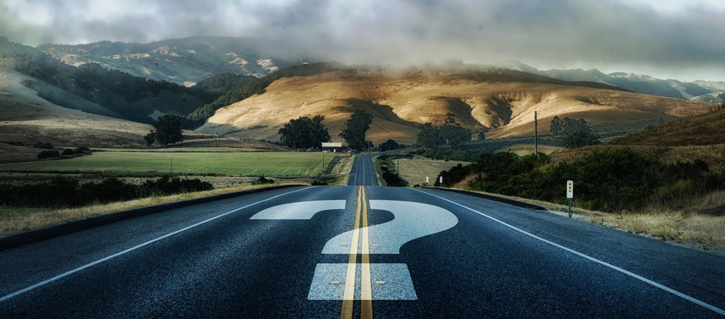

## Fuentes de incertidumbre.

**Datos**

Debido a que nuestros instrumentos de medición tienen un margen de error, se presentan datos imperfectos e incompletos, por lo tanto hay incertidumbre en los datos.

**Atributos del modelo**

Atributos del modelo: Son variables que representan un subconjunto reducido de toda la realidad del problema, estas variables provienen de los datos y por lo tanto presentan cierto grado de incertidumbre.

**Arquitectura del modelo**

Un modelo es una representación simplificada de la realidad y al ser así, por construcción, induce otra capa de incertidumbre, ya que al ser una representación simplificada se considera mucho menos información.

## Que es la probabilidad y que estudia?

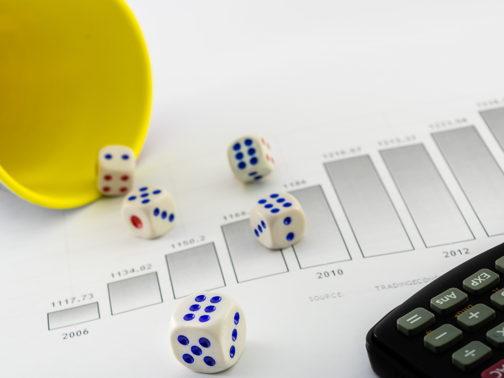

- El concepto intuitivo de probabilidad indica la posibilidad de la ocurrencia de un hecho o fenómeno.
- Ejemplos:
  - Tener un día soleado
  - Contraer una infección
  - Aprobar un examen de opción múltiple sin haber estudiado.
- La probabilidad ES una medida de la incertidumbre

## Que es la probabilidad y que estudia?

[figure not shown]

### Definiciones

- Un **experimento aleatorio** es un proceso en el que el resultado no puede ser predecido con certeza y que depende del azar.
- Un **Evento aleatorio o estocástico** es un subconjunto de los posibles resultados del experimento aleatorio.
- Una **variable aleatoria** es una función que asigna un valor a cada posible resultado de un experimento aleatorio.

## Dos ejemplos fundamentales

[figure not shown]

https://pacaicedo.github.io